# Convolutional Neural Networks II

# Disclaimer

This notebook was created for the SAV block course “Deep Learning with Actuarial Applications in R”.

The course is based on the publications on the following website: https://www.actuarialdatascience.org/

Author: Daniel Meier

# Applying Convolutional Neural Networks for classification of handwritten digits

## Abstract

The [MNIST dataset](http://yann.lecun.com/exdb/mnist/), i.e. images of handwriten digits to be recognized, is a standard dataset to illustrate the strengths of (deep) convolutional neural networks (CNNs). In this notebook we construct a 7-layer CNN (not counting the batch normalizations separately) with 3 pairs of a convolutional layer followed by max pooling, and a final fully connected layer with 10 outputs for each of the 10 digits.

## Introduction

The MNIST dataset consists of 70’000 monochrome pictures of pixel size 28 x 28 and is already split into a training set of 60’000 pictures and test set of 10’000 pictures.

The constructed CNN is a 7-layer network comprising

- a convolutional 2D layer: 10 filters of size 3 times 3 and stepsize 1 and 1,
- a max pooling layer: window size 2 times 2, stepsize 2 and 2,
- a convolutional 2D layer: 20 filters of size 3 times 3 and stepsize 1 and 1,
- a max pooling layer: window size 2 times 2, stepsize 1 and 1,
- a convolutional 2D layer: 40 filters of size 3 times 3 and stepsize 1 and 1,
- a max pooling layer: window size 2 times 2, stepsize 2 and 2,
- a fully connected layer.

We formulate the problem as a classification problem minimizing the categorical crossentropy and consider the resulting multi-class accuracy as metric.

In Section 0 we import all necessary modules and define the most relevant parameters. In Section 1 we load the MNIST dataset and plot some examples. Section 2 constructs the CNN and applies it on the MNIST dataset. Section 3 plots the accuracy history and the confusion matrix across all 10 digits, and Section 4 shows all wrongly classified images. Section 5 considers how translations, rotations, scalings affect model performance.

## 0. Import modules, definition of parameters

```r
options(encoding = 'UTF-8')

# Loading all the necessary packages
library("repr")  # not needed in the Rmarkdown version, only for Jupyter notebook
library("ggplot2")
library("keras")
library("tensorflow")
library("OpenImageR")
```

```r
knitr::opts_chunk$set(fig.width = 9, fig.height = 7)
#options(repr.plot.width=4, repr.plot.height=10)
```

```r
validationRatio <- 0.15
filterSize1     <- 3
numberFilters1  <- 10
filterSize2     <- 3
numberFilters2  <- 20
filterSize3     <- 3
numberFilters3  <- 40
numberEpochs    <- 10

dataRoot <- "../../data"
```

## 1. Loading the MNIST dataset

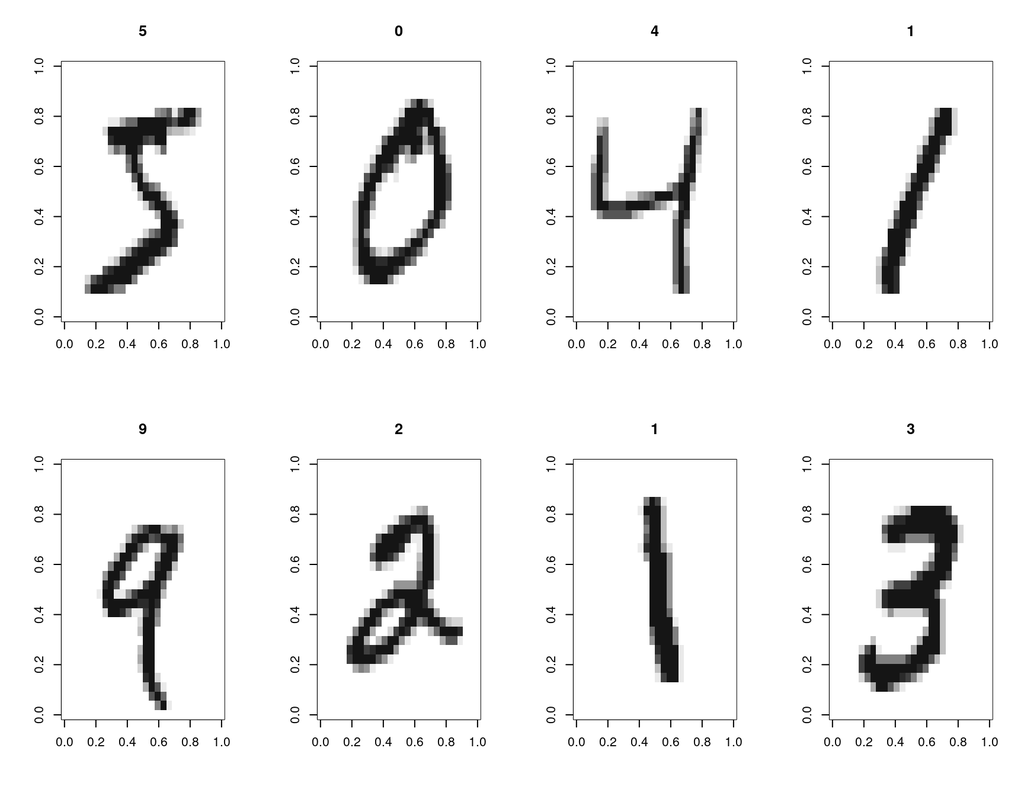

```r
load_image_file <- function(filename) {
  ret = list()
  f = file(filename, 'rb')
  readBin(f, 'integer', n = 1, size = 4, endian = 'big')
  n    = readBin(f, 'integer', n = 1, size = 4, endian = 'big')
  nrow = readBin(f, 'integer', n = 1, size = 4, endian = 'big')
  ncol = readBin(f, 'integer', n = 1, size = 4, endian = 'big')
  x = readBin(f, 'integer', n = n * nrow * ncol, size = 1, signed = FALSE)
  close(f)
  data.frame(matrix(x, ncol = nrow * ncol, byrow = TRUE))
}

load_label_file <- function(filename) {
  f = file(filename, 'rb')
  readBin(f, 'integer', n = 1, size = 4, endian = 'big')
  n = readBin(f, 'integer', n = 1, size = 4, endian = 'big')
  y = readBin(f, 'integer', n = n, size = 1, signed = FALSE)
  close(f)
  y
}

trainX <- load_image_file(file.path(dataRoot, "cnn2", "train-images.idx3-ubyte"))
testX  <- load_image_file(file.path(dataRoot, "cnn2", "t10k-images.idx3-ubyte"))

train_Y <- as.factor(load_label_file(file.path(dataRoot, "cnn2", "train-labels.idx1-ubyte")))
test_Y  <- as.factor(load_label_file(file.path(dataRoot, "cnn2", "t10k-labels.idx1-ubyte")))

trainX <- array_reshape(data.matrix(trainX) / 255, c(dim(trainX)[1], 28, 28, 1))
testX <- array_reshape(data.matrix(testX) / 255, c(dim(testX)[1], 28, 28, 1))
trainY <- to_categorical(train_Y, 10)
testY <- to_categorical(test_Y, 10)

par(mfrow = c(2, 4))
for (j in 1:8) {
    image(aperm(trainX[j, 28:1, , 1], c(2, 1)), col = gray(12:1 / 12))
    title(train_Y[j])
}
```

## 2. Constructing and fitting the CNN

```r
set.seed(0)
tf$random$set_seed(0)

cnn <- keras_model_sequential() %>%
  layer_conv_2d(filters = numberFilters1, kernel_size = c(filterSize1, filterSize1),
                strides = c(1,1), padding = 'valid', input_shape = c(28, 28, 1)) %>%
  layer_batch_normalization() %>%
  layer_activation('relu') %>%
  layer_max_pooling_2d(pool_size = c(2,2), strides = c(2,2), padding = 'valid') %>%

  layer_conv_2d(filters = numberFilters2, kernel_size = c(filterSize2, filterSize2),
                strides = c(1,1), padding = 'valid') %>%
  layer_batch_normalization() %>%
  layer_activation('relu') %>%
  layer_max_pooling_2d(pool_size = c(2,2), strides = c(1,1), padding = 'valid') %>%

  layer_conv_2d(filters = numberFilters3, kernel_size = c(filterSize3, filterSize3),
                strides = c(1,1), padding = 'valid') %>%
  layer_batch_normalization() %>%
  layer_activation('relu') %>%
  layer_max_pooling_2d(pool_size = c(2,2), strides = c(2,2)) %>%

  layer_flatten() %>%
  layer_dense(10) %>%
  layer_activation('softmax', name = 'softmax') %>%
  compile(loss = loss_categorical_crossentropy, optimizer = optimizer_adadelta(), metrics = c('accuracy'))

# RSc: below took ~22 minutes with 1CPU / 8GB / 40 epochs
summary <- cnn %>% fit(
  x = trainX,
  y = trainY,
  epochs = numberEpochs,
  validation_split = validationRatio,
  batch_size = 64,
  verbose = 1
)
summary(cnn)
```

```
## Model: "sequential"
## ________________________________________________________________________________
## Layer (type)                        Output Shape                    Param #
## ================================================================================
## conv2d_2 (Conv2D)                   (None, 26, 26, 10)              100
## ________________________________________________________________________________
## batch_normalization_2 (BatchNormali (None, 26, 26, 10)              40
## ________________________________________________________________________________
## activation_2 (Activation)           (None, 26, 26, 10)              0
## ________________________________________________________________________________
## max_pooling2d_2 (MaxPooling2D)      (None, 13, 13, 10)              0
## ________________________________________________________________________________
## conv2d_1 (Conv2D)                   (None, 11, 11, 20)              1820
## ________________________________________________________________________________
## batch_normalization_1 (BatchNormali (None, 11, 11, 20)              80
## ________________________________________________________________________________
## activation_1 (Activation)           (None, 11, 11, 20)              0
## ________________________________________________________________________________
## max_pooling2d_1 (MaxPooling2D)      (None, 10, 10, 20)              0
## ________________________________________________________________________________
## conv2d (Conv2D)                     (None, 8, 8, 40)                7240
## ________________________________________________________________________________
## batch_normalization (BatchNormaliza (None, 8, 8, 40)                160
## ________________________________________________________________________________
## activation (Activation)             (None, 8, 8, 40)                0
## ________________________________________________________________________________
## max_pooling2d (MaxPooling2D)        (None, 4, 4, 40)                0
## ________________________________________________________________________________
## flatten (Flatten)                   (None, 640)                     0
## ________________________________________________________________________________
## dense (Dense)                       (None, 10)                      6410
## ________________________________________________________________________________
## softmax (Activation)                (None, 10)                      0
## ================================================================================
## Total params: 15,850
## Trainable params: 15,710
## Non-trainable params: 140
## ________________________________________________________________________________
```

## 3. Accuracy history and confusion matrix

**Exercise:** Experiment with other structures/parameters of the CNN. Make use of summary(cnn) to check the dimensions of inputs/outputs of each layer. How are the dimensions affected by strides, padding, kernel_size, number of filters?

**Exercise:** Change the random seeds (`set.seed(0)` and `tf$random$set_seed(0)`). If you keep the random seeds, are the results 100% reproducible?

**Exercise:** Change the relu activation functions to some other activation functions.

**Exercise:** The input images are gray scale images. Turn them into black-white images (only allowing values 0 and 1) and refit the model.

**Exercise:** Introduce some random noise in the images, e.g. by adding i.i. uniformly distributed numbers out of the interval [-r,r]. Plot r vs accuracy for some selected r.

**Exercise:** Set 0<r<28^2 random pixels to white and plot r vs accuracy for some selected r.

**Exercise:** There are several other structures/parameters to be found in the web, e.g. https://keras.rstudio.com/articles/examples/mnist_cnn.html, or https://tensorflow.rstudio.com/guide/keras/, etc. not all of them necessarily make use of convolutional layers. What are the main differences between these structures? Advantages/disadvantages? Which performs best?

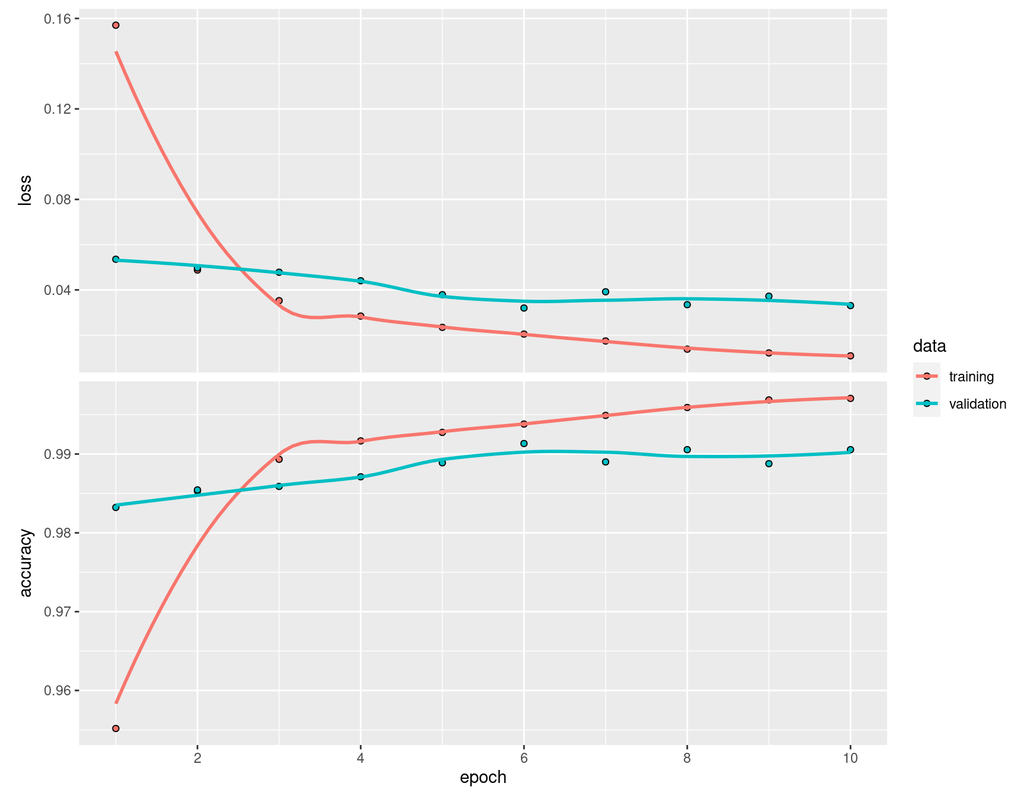

```r
plot(summary)
```

```r
print(summary)
```

```
##
## Final epoch (plot to see history):
##         loss: 0.01086
##     accuracy: 0.9971
##     val_loss: 0.03306
## val_accuracy: 0.9906
```

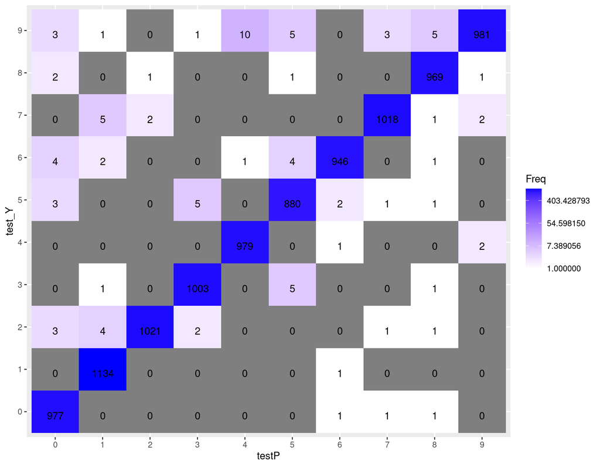

```r
#testP <- cnn %>% predict_classes(testX)  # This is deprecated in keras/tf 2.6. In our case, below is applicable instead.
testP <- cnn %>% predict(testX) %>% k_argmax()
testP <- as.array(testP)

confusion_matrix <- as.data.frame(table(testP, test_Y))

ggplot(data = confusion_matrix, aes(x = testP, y = test_Y)) +
  geom_tile(aes(fill = Freq)) +
  geom_text(aes(label = sprintf("%1.0f", Freq)), vjust = 1) +
  scale_fill_gradient(low = "white", high = "blue", trans = "log")
```

## 4. Wrongly classified images

Images where the actual image differs from the predicted image (denoted as A and P) are shown in this section.

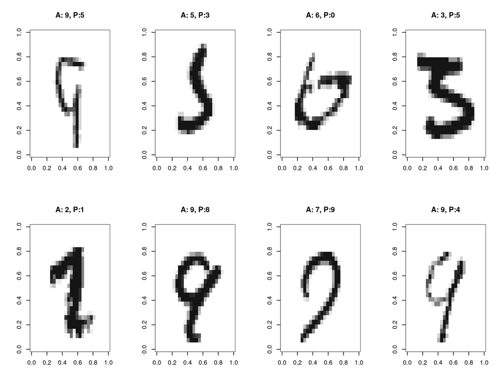

```r
incorrectIdx <- which(test_Y != testP)
par(mfrow = c(2, 4))
for (j in 1:8) {
    image(aperm(testX[incorrectIdx[j], 28:1, , 1], c(2,1)), col = gray(12:1 / 12))
    title(paste0('A: ', test_Y[incorrectIdx[j]], ', P:', testP[incorrectIdx[j]]))
}
```

```r
print(paste(length(incorrectIdx), "incorrectly classified digits (out of 10'000 digits)"))
```

```
## [1] "92 incorrectly classified digits (out of 10'000 digits)"
```

## 5. Rotations, translations, scalings

The following 3 cells (chunks) rotate, translate and scale images. Observe how the model predictions (the softmax layer) are impacted by these transformations.

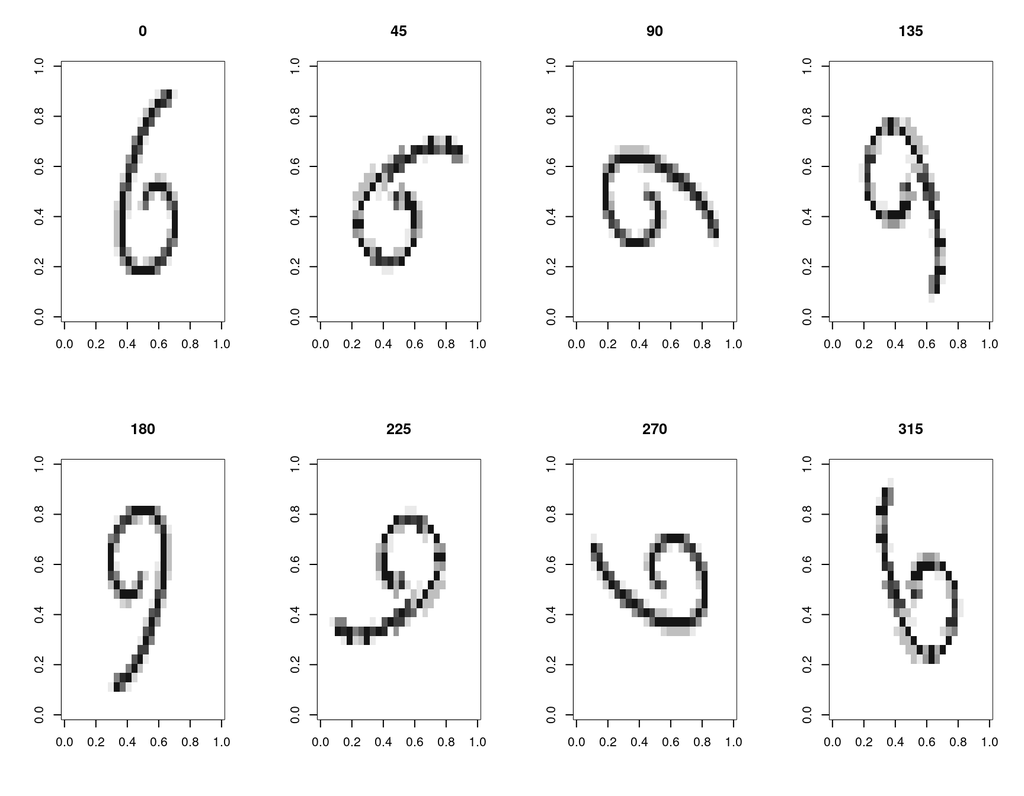

```r
layerModel <- keras_model(input = cnn$input, outputs = get_layer(cnn, 'softmax')$output)  # the softmax activation layer
img <- trainX[19, 28:1, , ]
par(mfrow = c(2, 4))
for (j in seq(0, 315, 45)) {
    image(aperm(rotateImage(img, j), c(2,1)), col = gray(12:1 / 12))
    title(j)
}
```

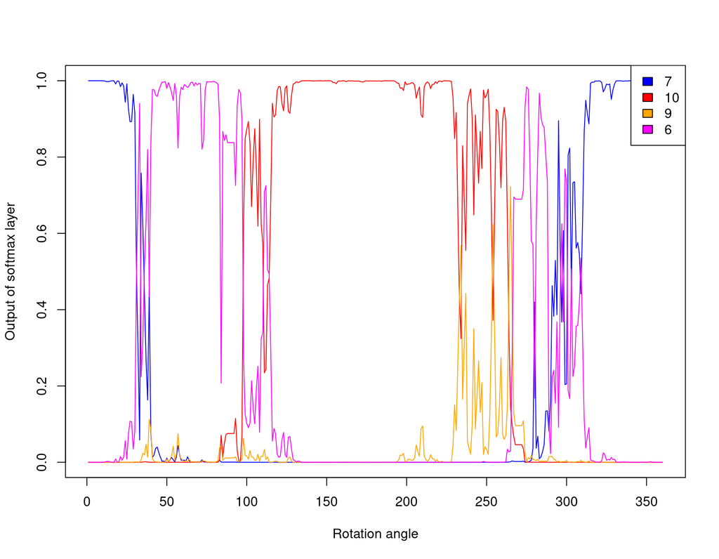

```r
activationSoftMax <- matrix(0, 360, 10)
for (j in 1:360) {
    imgRotated <- img
    imgRotated <- rotateImage(img, j)[28:1, ]
    activationSoftMax[j, ] <- layerModel %>% predict(array_reshape(imgRotated, c(1, 28, 28, 1)))
}

par(mfrow = c(1, 1))
plot(1:360, activationSoftMax[, 7], type = "l", col = "blue", xlab = "Rotation angle", ylab = "Output of softmax layer")
lines(1:360, activationSoftMax[, 10], col = "red")
lines(1:360, activationSoftMax[, 9], col = "orange")
lines(1:360, activationSoftMax[, 6], col = "magenta")
legend("topright", legend = c("7", "10", "9", "6"), fill = c("blue", "red", "orange", "magenta"))
```

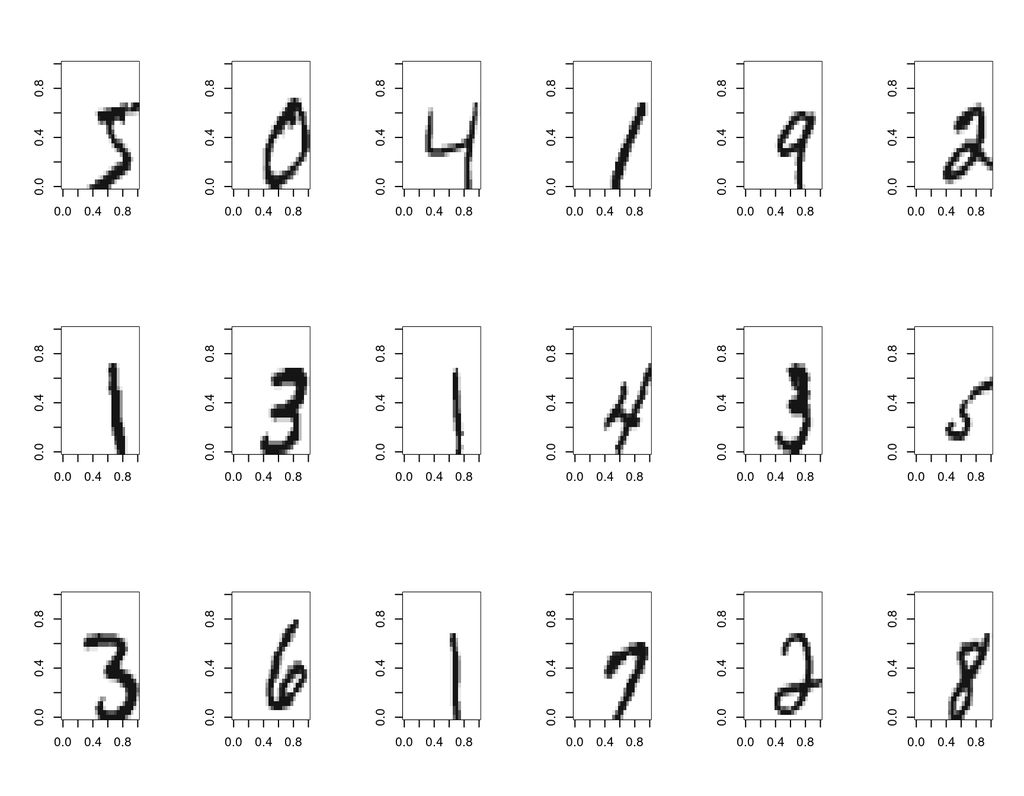

```r
activationSoftMax <- array(0, c(121, 10, 18))
par(mfrow = c(3, 6))
for (i in 1:18) {
    img <- trainX[i, , , ]
    for (j in 1:121) {
        shiftRows <- j %% 11 - 5
        shiftCols <- floor(j / 11) - 5
        if (shiftRows != 0 && shiftCols != 0)
          imgShifted <- translation(img, shift_rows = shiftRows, shift_cols = shiftCols)
        else
          imgShifted <- img
        activationSoftMax[j, , i] <- layerModel %>% predict(array_reshape(imgShifted, c(1, 28, 28, 1)))
        if (j == 1) {
            lowerRight <- imgShifted
        }
    }
    image(aperm(lowerRight[28:1, ], c(2, 1)), col = gray(12:1 / 12))
}
```

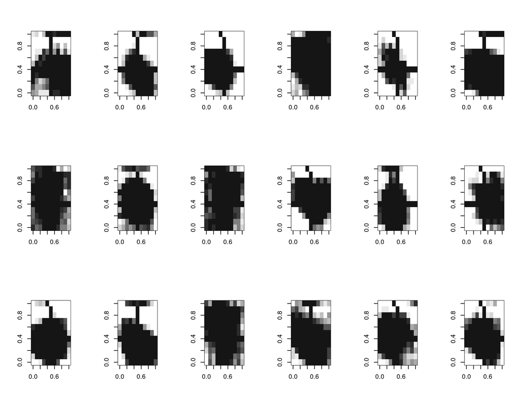

```r
par(mfrow = c(3, 6))
for (i in 1:18) {
    image(array_reshape(activationSoftMax[, as.numeric(train_Y[i]), i], c(11, 11)), col = gray(12:1 / 12))
}
```

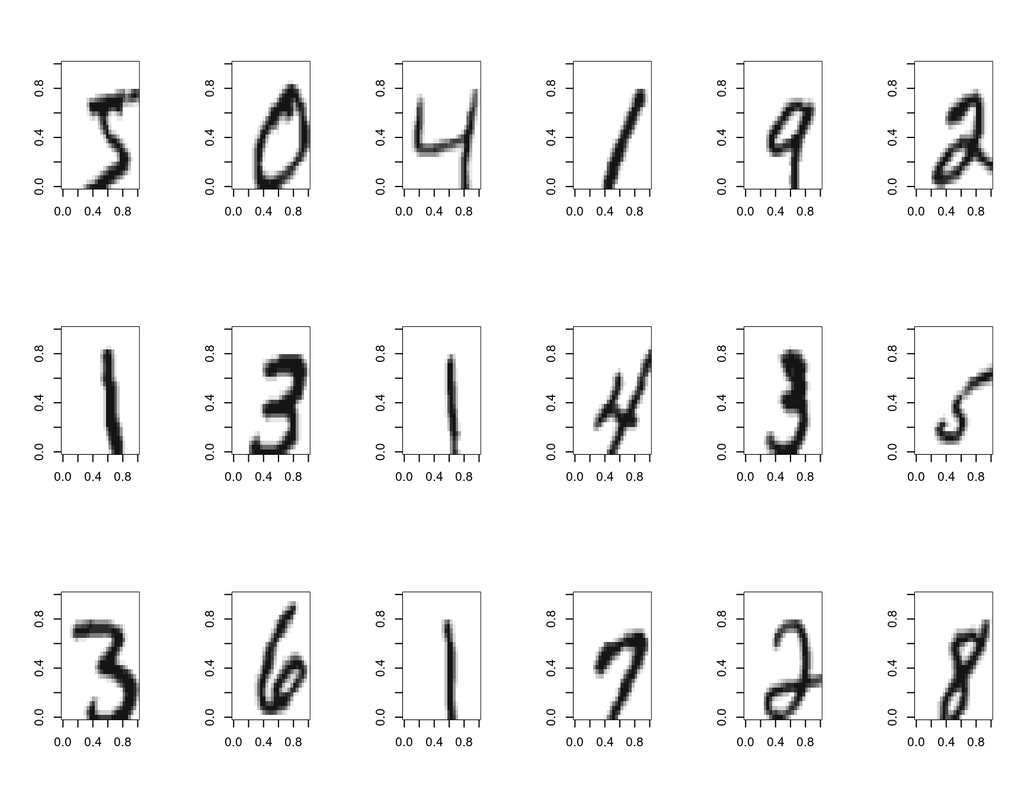

```r
activationSoftMax <- array(0, c(121, 10, 18))
par(mfrow = c(3, 6))
for (i in 1:18) {
    img <- trainX[i, , , ]
    for (j in 1:121) {
        imgZoomed <- cropImage(
          resizeImage(img, height = round(28*((j%%11)/20+1)), width = round(28*((floor(j/11))/20+1)), method = "bilinear"),
          new_height = 1:28,
          new_width = 1:28,
          type = "user_defined"
        )
        activationSoftMax[j, , i] <- layerModel %>% predict(array_reshape(imgZoomed, c(1, 28, 28, 1)))
        if (j == 48) {
            selectedImgZoom <- imgZoomed
        }
    }
    image(aperm(selectedImgZoom[28:1, ], c(2, 1)), col = gray(12:1 / 12))
}
```

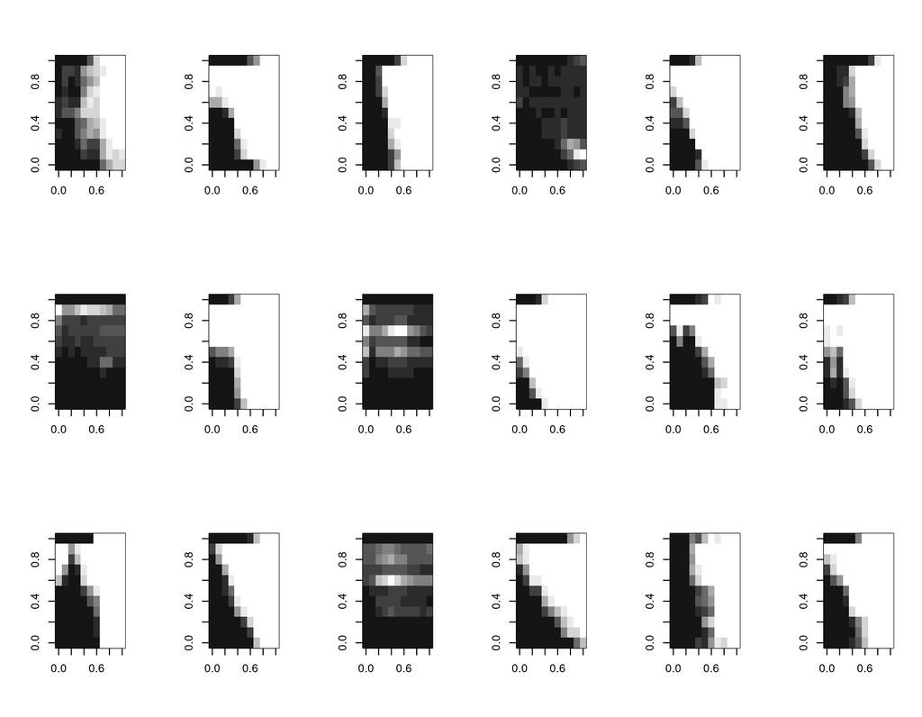

```r
par(mfrow = c(3, 6))
for (i in 1:18) {
    image(array_reshape(activationSoftMax[, as.numeric(train_Y[i]), i], c(11, 11)), col = gray(12:1 / 12))
}
```